# FinalProject Question3

TeamProject

December 17, 2018

## Option Delta Hedging(Real-World)

Delta hedging is an options strategy that aims to reduce, or hedge, the risk associated with price movements in the underlying asset, by offsetting long and short positions. For example, a long call position may be delta hedged by shorting the underlying stock.

Here we are showcasing with an example how does this data hedging work as a trading strategy.Also backtesting the same with past 1 year data.

To illustrate this we have chosen Goldman stock Stock price. Let’s see how option hedging works as a strategy with this stock.

We have taken assumptions provided in question for the analysis. Firstly, we have pooled relevant option price,stock price ,implied volatility of Goldman Sach Group stock.Created data xts object from the data.

In order to proceed with this trade analysis we have created a dataframe with data column initally.

# Dec-Jan

| date | Close | IV30 | Previous_Close | monthnumber | premium | Option_DoD_PnL | delta_hedge | Hedging_DoD_Pnl | Net_PnL |
| --- | --- | --- | --- | --- | --- | --- | --- | --- | --- |
| 2017-12-15 | 118.19 | 15.6 | 116.46 | 1 | 1.4034067 | -140.340672 | -40 | -69.20 | -209.540672 |
| 2017-12-18 | 118.64 | 15.2 | 118.19 | 1 | 2.0929179 | 68.951116 | -54 | -24.30 | 44.651116 |
| 2017-12-19 | 118.34 | 15.2 | 118.64 | 1 | 2.3007107 | 20.779279 | -57 | 17.10 | 37.879279 |
| 2017-12-20 | 117.86 | 15.5 | 118.34 | 1 | 2.0899594 | -21.075122 | -55 | 26.40 | 5.324878 |
| 2017-12-21 | 117.40 | 15.9 | 117.86 | 1 | 1.7933388 | -29.662070 | -51 | 23.46 | -6.202070 |
| 2017-12-22 | 116.88 | 15.2 | 117.40 | 1 | 1.5260828 | -26.725591 | -46 | 23.92 | -2.805591 |
| 2017-12-26 | 117.57 | 15.0 | 116.88 | 1 | 1.1173613 | -40.872154 | -40 | -27.60 | -68.472154 |
| 2017-12-27 | 117.26 | 14.9 | 117.57 | 1 | 1.3703948 | 25.303346 | -47 | 14.57 | 39.873346 |
| 2017-12-28 | 117.31 | 14.8 | 117.26 | 1 | 1.1788804 | -19.151434 | -44 | -2.20 | -21.351434 |
| 2017-12-29 | 117.19 | 15.8 | 117.31 | 1 | 1.1487755 | -3.010491 | -44 | 5.28 | 2.269509 |
| 2018-01-02 | 115.99 | 18.9 | 117.19 | 1 | 0.8713978 | -27.737770 | -41 | 49.20 | 21.462230 |
| 2018-01-03 | 117.25 | 19.8 | 115.99 | 1 | 0.4207068 | -45.069098 | -25 | -31.50 | -76.569098 |
| 2018-01-04 | 118.37 | 20.3 | 117.25 | 1 | 0.7673752 | 34.666841 | -40 | -44.80 | -10.133159 |
| 2018-01-05 | 118.30 | 20.9 | 118.37 | 1 | 1.2362436 | 46.886835 | -57 | 3.99 | 50.876835 |
| 2018-01-08 | 117.94 | 20.7 | 118.30 | 1 | 0.9416708 | -29.457277 | -57 | 20.52 | -8.937277 |
| 2018-01-09 | 118.76 | 20.1 | 117.94 | 1 | 0.6442215 | -29.744937 | -49 | -40.18 | -69.924937 |
| 2018-01-10 | 117.65 | 20.2 | 118.76 | 1 | 1.0155276 | 37.130613 | -72 | 79.92 | 117.050613 |
| 2018-01-11 | 117.18 | 21.2 | 117.65 | 1 | 0.2359447 | -77.958291 | -36 | 16.92 | -61.038291 |
| 2018-01-12 | 118.47 | 21.0 | 117.18 | 1 | 0.0000000 | -23.594467 | 0 | 0.00 | -23.594467 |

```
## [1] 437.68
```

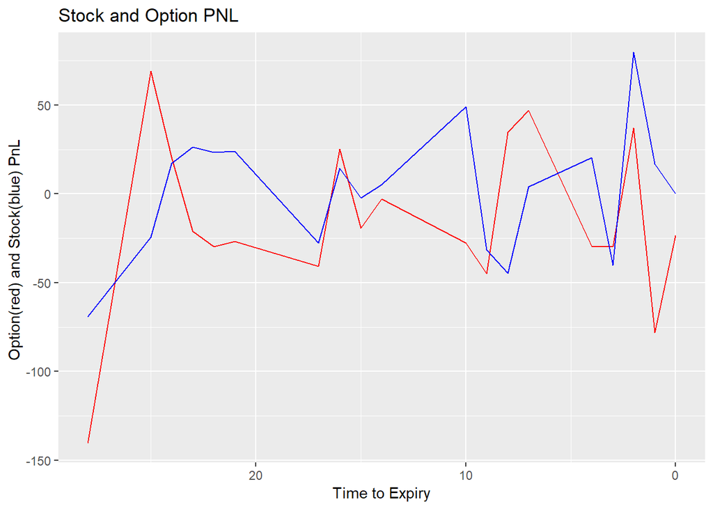

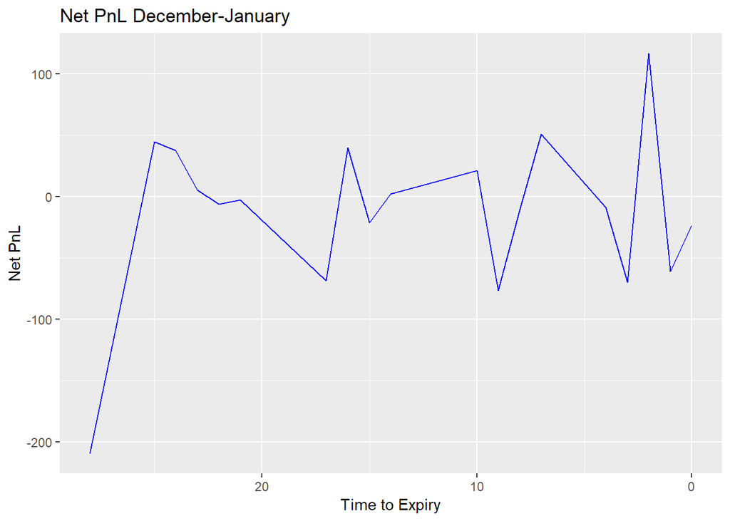

```
## Final Net cumulative profit for this month  -239.1813
```

```
## character(0)
```

# MONTH JAN-FEB

| date | Close | IV30 | Previous_Close | monthnumber | premium | Option_DoD_PnL | delta_hedge | Hedging_DoD_Pnl | Net_PnL |
| --- | --- | --- | --- | --- | --- | --- | --- | --- | --- |
| 2018-01-16 | 119.39 | 20.3 | 118.47 | 2 | 1.7114814 | -171.1481356 | -38 | -34.96 | -206.1081356 |
| 2018-01-17 | 122.05 | 20.9 | 119.39 | 2 | 2.0323585 | 32.0877176 | -43 | -114.38 | -82.2922824 |
| 2018-01-18 | 120.90 | 21.0 | 122.05 | 2 | 3.3224005 | 129.0041919 | -58 | 66.70 | 195.7041919 |
| 2018-01-19 | 121.44 | 20.7 | 120.90 | 2 | 2.6386932 | -68.3707242 | -51 | -27.54 | -95.9107242 |
| 2018-01-22 | 122.77 | 20.4 | 121.44 | 2 | 2.7608037 | 12.2110527 | -55 | -73.15 | -60.9389473 |
| 2018-01-23 | 122.10 | 20.5 | 122.77 | 2 | 3.4890156 | 72.8211828 | -63 | 42.21 | 115.0311828 |
| 2018-01-24 | 120.86 | 20.3 | 122.10 | 2 | 3.0215791 | -46.7436432 | -59 | 73.16 | 26.4163568 |
| 2018-01-25 | 120.63 | 21.0 | 120.86 | 2 | 2.2797128 | -74.1866355 | -51 | 11.73 | -62.4566355 |
| 2018-01-26 | 122.33 | 21.9 | 120.63 | 2 | 2.1040287 | -17.5684054 | -49 | -83.30 | -100.8684054 |
| 2018-01-29 | 120.76 | 22.3 | 122.33 | 2 | 2.8515213 | 74.7492553 | -62 | 97.34 | 172.0892553 |
| 2018-01-30 | 120.81 | 23.9 | 120.76 | 2 | 1.9083771 | -94.3144186 | -50 | -2.50 | -96.8144186 |
| 2018-01-31 | 123.63 | 16.7 | 120.81 | 2 | 1.8631844 | -4.5192739 | -50 | -141.00 | -145.5192739 |
| 2018-02-01 | 120.42 | 16.6 | 123.63 | 2 | 3.5252277 | 166.2043389 | -72 | 231.12 | 397.3243389 |
| 2018-02-02 | 118.57 | 18.0 | 120.42 | 2 | 1.5285099 | -199.6717887 | -46 | 85.10 | -114.5717887 |
| 2018-02-05 | 114.07 | 21.3 | 118.57 | 2 | 0.6201893 | -90.8320531 | -27 | 121.50 | 30.6679469 |
| 2018-02-06 | 112.95 | 25.0 | 114.07 | 2 | 0.0342553 | -58.5934008 | -3 | 3.36 | -55.2334008 |
| 2018-02-07 | 113.56 | 21.0 | 112.95 | 2 | 0.0079885 | -2.6266772 | -1 | -0.61 | -3.2366772 |
| 2018-02-08 | 108.25 | 27.1 | 113.56 | 2 | 0.0076415 | -0.0347068 | -1 | 5.31 | 5.2752932 |
| 2018-02-09 | 111.43 | 27.5 | 108.25 | 2 | 0.0000008 | -0.7640693 | 0 | 0.00 | -0.7640693 |
| 2018-02-12 | 111.65 | 23.7 | 111.43 | 2 | 0.0000000 | -0.0000774 | 0 | 0.00 | -0.0000774 |
| 2018-02-13 | 111.82 | 22.1 | 111.65 | 2 | 0.0000000 | -0.0000006 | 0 | 0.00 | -0.0000006 |
| 2018-02-14 | 112.71 | 20.1 | 111.82 | 2 | 0.0000000 | 0.0000000 | 0 | 0.00 | 0.0000000 |

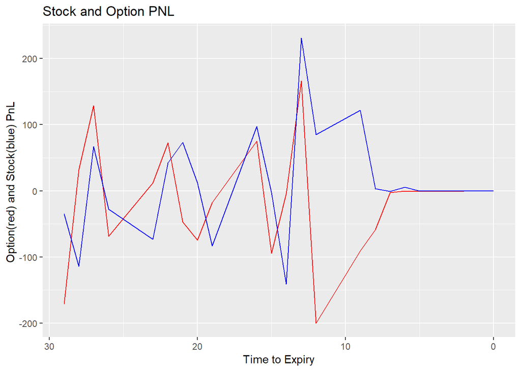

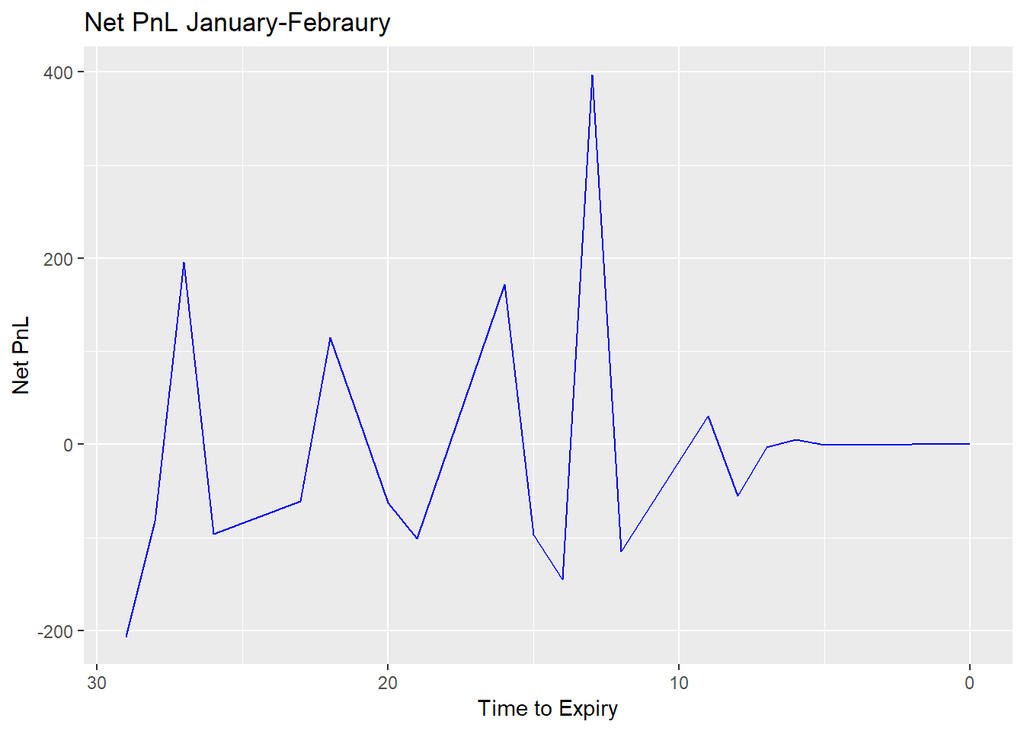

```
## Final Net cumulative profit for this month  -82.20627
```

```
## character(0)
```

# MONTH FEB-MARCH

| date | Close | IV30 | Previous_Close | monthnumber | premium | Option_DoD_PnL | delta_hedge | Hedging_DoD_Pnl | Net_PnL |
| --- | --- | --- | --- | --- | --- | --- | --- | --- | --- |
| 2018-02-15 | 115.51 | 19.2 | 112.71 | 3 | 1.1328663 | -113.28663 | -31 | -86.80 | -200.086630 |
| 2018-02-16 | 116.18 | 18.6 | 115.51 | 3 | 2.1966374 | 106.37711 | -49 | -32.83 | 73.547106 |
| 2018-02-20 | 115.41 | 18.5 | 116.18 | 3 | 2.3368069 | 14.01695 | -53 | 40.81 | 54.826951 |
| 2018-02-21 | 116.10 | 18.4 | 115.41 | 3 | 1.8967144 | -44.00925 | -47 | -32.43 | -76.439247 |
| 2018-02-22 | 115.43 | 18.6 | 116.10 | 3 | 2.1873724 | 29.06580 | -53 | 35.51 | 64.575799 |
| 2018-02-23 | 117.65 | 17.3 | 115.43 | 3 | 1.7977615 | -38.96109 | -47 | -104.34 | -143.301088 |
| 2018-02-26 | 117.90 | 17.2 | 117.65 | 3 | 2.8697074 | 107.19459 | -65 | -16.25 | 90.944592 |
| 2018-02-27 | 116.47 | 18.0 | 117.90 | 3 | 2.9771609 | 10.74535 | -68 | 97.24 | 107.985349 |
| 2018-02-28 | 115.32 | 18.6 | 116.47 | 3 | 2.0308278 | -94.63331 | -56 | 64.40 | -30.233312 |
| 2018-03-01 | 113.79 | 20.4 | 115.32 | 3 | 1.3851079 | -64.57199 | -45 | 68.85 | 4.278014 |
| 2018-03-02 | 113.60 | 20.1 | 113.79 | 3 | 0.7473326 | -63.77753 | -30 | 5.70 | -58.077534 |
| 2018-03-05 | 115.66 | 18.4 | 113.60 | 3 | 0.5120479 | -23.52847 | -25 | -51.50 | -75.028473 |
| 2018-03-06 | 115.41 | 18.6 | 115.66 | 3 | 1.1707401 | 65.86923 | -47 | 11.75 | 77.619226 |
| 2018-03-07 | 115.18 | 19.2 | 115.41 | 3 | 0.9711844 | -19.95557 | -43 | 9.89 | -10.065575 |
| 2018-03-08 | 116.96 | 18.3 | 115.18 | 3 | 0.7847390 | -18.64454 | -40 | -71.20 | -89.844536 |
| 2018-03-09 | 118.83 | 17.5 | 116.96 | 3 | 1.6114926 | 82.67536 | -65 | -121.55 | -38.874637 |
| 2018-03-12 | 117.53 | 17.6 | 118.83 | 3 | 2.8714616 | 125.99689 | -96 | 124.80 | 250.796894 |
| 2018-03-13 | 117.39 | 17.4 | 117.53 | 3 | 1.5879942 | -128.34674 | -91 | 12.74 | -115.606743 |
| 2018-03-14 | 116.10 | 17.6 | 117.39 | 3 | 1.3900000 | -19.79942 | -100 | 129.00 | 109.200585 |

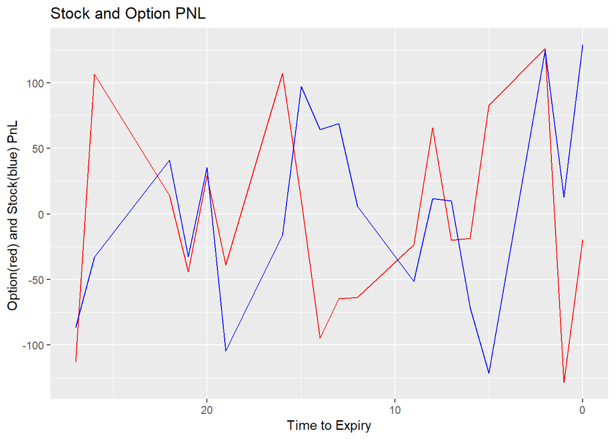

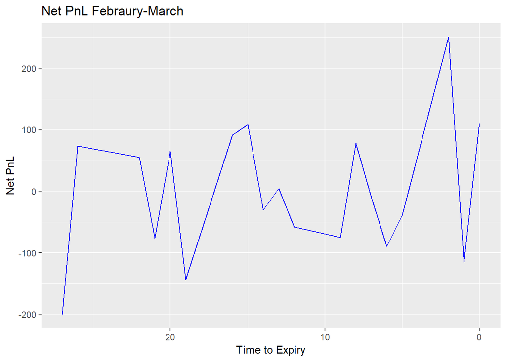

```
## Final Net cumulative profit for this month  -3.78326
```

```
## character(0)
```

# MONTH MARCH-APRIL

| date | Close | IV30 | Previous_Close | monthnumber | premium | Option_DoD_PnL | delta_hedge | Hedging_DoD_Pnl | Net_PnL |
| --- | --- | --- | --- | --- | --- | --- | --- | --- | --- |
| 2018-03-15 | 116.48 | 17.1 | 116.10 | 4 | 1.4871216 | -148.7121596 | -39 | -14.82 | -163.5321596 |
| 2018-03-16 | 117.16 | 16.6 | 116.48 | 4 | 1.5993880 | 11.2266368 | -41 | -27.88 | -16.6533632 |
| 2018-03-19 | 114.48 | 18.7 | 117.16 | 4 | 1.7673812 | 16.7993202 | -46 | 123.28 | 140.0793202 |
| 2018-03-20 | 115.56 | 18.1 | 114.48 | 4 | 0.7726025 | -99.4778649 | -26 | -28.08 | -127.5578649 |
| 2018-03-21 | 116.36 | 18.7 | 115.56 | 4 | 1.0524521 | 27.9849590 | -33 | -26.40 | 1.5849590 |
| 2018-03-22 | 113.14 | 22.1 | 116.36 | 4 | 1.2962195 | 24.3767403 | -39 | 125.58 | 149.9567403 |
| 2018-03-23 | 109.20 | 24.6 | 113.14 | 4 | 0.3939562 | -90.2263287 | -16 | 63.04 | -27.1863287 |
| 2018-03-26 | 114.06 | 22.3 | 109.20 | 4 | 0.0348219 | -35.9134366 | -2 | -9.72 | -45.6334366 |
| 2018-03-27 | 112.26 | 24.1 | 114.06 | 4 | 0.4312186 | 39.6396712 | -19 | 34.20 | 73.8396712 |
| 2018-03-28 | 111.76 | 24.8 | 112.26 | 4 | 0.1607621 | -27.0456501 | -9 | 4.50 | -22.5456501 |
| 2018-03-29 | 113.48 | 22.5 | 111.76 | 4 | 0.1047670 | -5.5995048 | -6 | -10.32 | -15.9195048 |
| 2018-04-02 | 113.30 | 24.9 | 113.48 | 4 | 0.1569999 | 5.2232905 | -10 | 1.80 | 7.0232905 |
| 2018-04-03 | 114.04 | 25.5 | 113.30 | 4 | 0.1149926 | -4.2007283 | -8 | -5.92 | -10.1207283 |
| 2018-04-04 | 116.72 | 24.9 | 114.04 | 4 | 0.1558049 | 4.0812262 | -11 | -29.48 | -25.3987738 |
| 2018-04-05 | 117.51 | 24.6 | 116.72 | 4 | 0.6685425 | 51.2737569 | -34 | -26.86 | 24.4137569 |
| 2018-04-06 | 113.70 | 26.1 | 117.51 | 4 | 0.9014991 | 23.2956619 | -44 | 167.64 | 190.9356619 |
| 2018-04-09 | 114.44 | 25.3 | 113.70 | 4 | 0.0148425 | -88.6656564 | -2 | -1.48 | -90.1456564 |
| 2018-04-10 | 115.91 | 24.7 | 114.44 | 4 | 0.0167093 | 0.1866735 | -3 | -4.41 | -4.2233265 |
| 2018-04-11 | 115.58 | 24.1 | 115.91 | 4 | 0.0537677 | 3.7058467 | -8 | 2.64 | 6.3458467 |
| 2018-04-12 | 115.26 | 24.0 | 115.58 | 4 | 0.0037184 | -5.0049370 | -1 | 0.32 | -4.6849370 |
| 2018-04-13 | 115.27 | 23.7 | 115.26 | 4 | 0.0000000 | -0.3718361 | 0 | 0.00 | -0.3718361 |

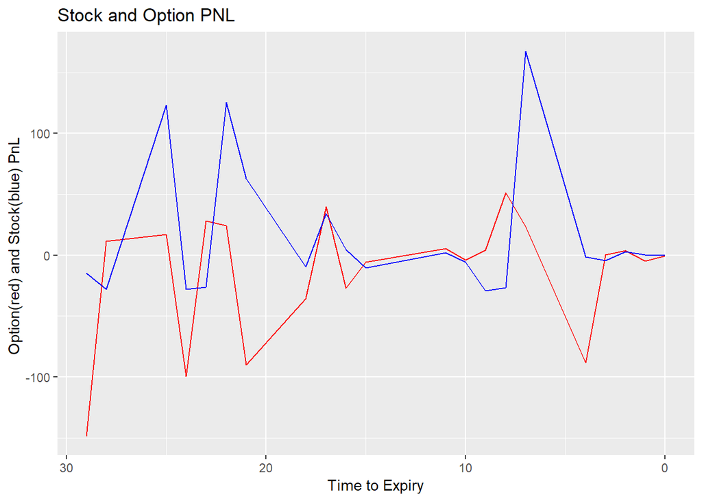

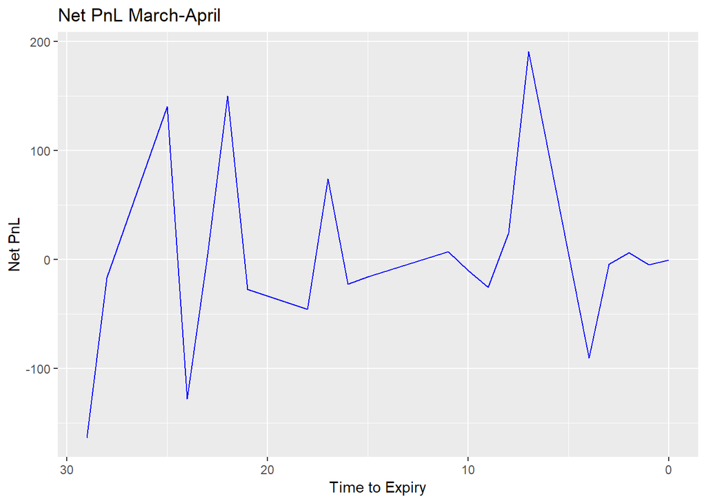

```
## Final Net cumulative profit for this month  40.20568
```

```
## character(0)
```

# MONTH APRIL-MAY

| date | Close | IV30 | Previous_Close | monthnumber | premium | Option_DoD_PnL | delta_hedge | Hedging_DoD_Pnl | Net_PnL |
| --- | --- | --- | --- | --- | --- | --- | --- | --- | --- |
| 2018-04-16 | 116.91 | 21.6 | 115.27 | 5 | 2.054482 | -205.448217 | -42 | -68.88 | -274.328217 |
| 2018-04-17 | 117.89 | 21.4 | 116.91 | 5 | 2.770747 | 71.626434 | -52 | -50.96 | 20.666434 |
| 2018-04-18 | 118.61 | 21.0 | 117.89 | 5 | 3.249699 | 47.895266 | -57 | -41.04 | 6.855266 |
| 2018-04-19 | 117.75 | 21.6 | 118.61 | 5 | 3.622493 | 37.279403 | -61 | 52.46 | 89.739403 |
| 2018-04-20 | 116.84 | 22.2 | 117.75 | 5 | 3.059037 | -56.345623 | -57 | 51.87 | -4.475623 |
| 2018-04-23 | 117.10 | 21.7 | 116.84 | 5 | 2.394742 | -66.429506 | -51 | -13.26 | -79.689506 |
| 2018-04-24 | 116.32 | 22.8 | 117.10 | 5 | 2.467863 | 7.312101 | -52 | 40.56 | 47.872101 |
| 2018-04-25 | 116.70 | 23.3 | 116.32 | 5 | 2.017407 | -45.045599 | -47 | -17.86 | -62.905599 |
| 2018-04-26 | 118.69 | 22.0 | 116.70 | 5 | 2.137185 | 11.977838 | -50 | -99.50 | -87.522162 |
| 2018-04-27 | 119.88 | 21.8 | 118.69 | 5 | 3.198592 | 106.140687 | -64 | -76.16 | 29.980687 |
| 2018-04-30 | 118.08 | 22.5 | 119.88 | 5 | 3.816735 | 61.814251 | -73 | 131.40 | 193.214251 |
| 2018-05-01 | 118.80 | 24.4 | 118.08 | 5 | 2.542654 | -127.408085 | -60 | -43.20 | -170.608085 |
| 2018-05-02 | 122.06 | 18.2 | 118.80 | 5 | 2.924157 | 38.150290 | -66 | -215.16 | -177.009710 |
| 2018-05-03 | 123.10 | 18.2 | 122.06 | 5 | 5.404623 | 248.046583 | -88 | -91.52 | 156.526583 |
| 2018-05-04 | 125.36 | 18.1 | 123.10 | 5 | 6.302660 | 89.803776 | -93 | -210.18 | -120.376224 |
| 2018-05-07 | 125.57 | 17.0 | 125.36 | 5 | 8.412878 | 211.021795 | -99 | -20.79 | 190.231795 |
| 2018-05-08 | 125.77 | 17.4 | 125.57 | 5 | 8.610111 | 19.723241 | -100 | -20.00 | -0.276759 |
| 2018-05-09 | 127.04 | 17.2 | 125.77 | 5 | 8.800695 | 19.058426 | -100 | -127.00 | -107.941574 |
| 2018-05-10 | 127.39 | 17.2 | 127.04 | 5 | 10.063293 | 126.259840 | -100 | -35.00 | 91.259840 |
| 2018-05-11 | 127.34 | 18.2 | 127.39 | 5 | 10.407434 | 34.414078 | -100 | 5.00 | 39.414078 |
| 2018-05-14 | 126.68 | 17.9 | 127.34 | 5 | 10.340000 | -6.743413 | -100 | 66.00 | 59.256587 |

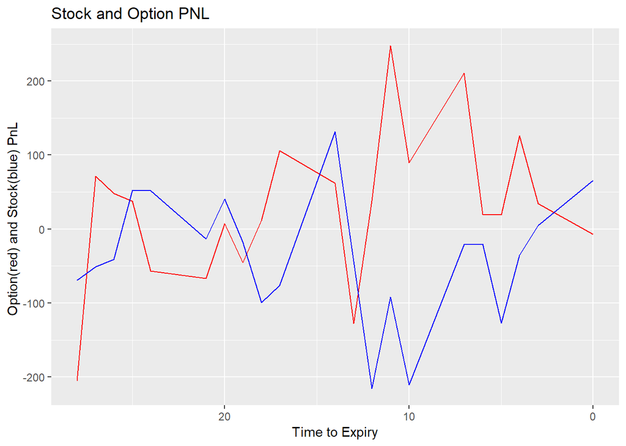

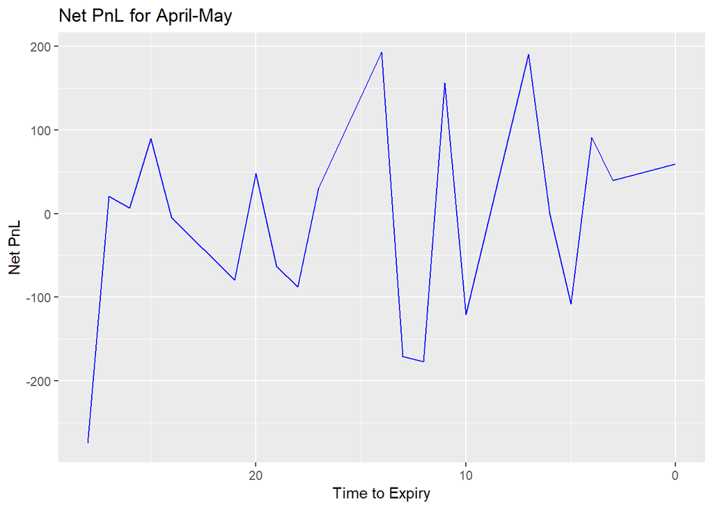

```
## Final Net cumulative profit for this month  -160.1164
```

```
## character(0)
```

# MONTH MAY-JUNE

| date | Close | IV30 | Previous_Close | monthnumber | premium | Option_DoD_PnL | delta_hedge | Hedging_DoD_Pnl | Net_PnL |
| --- | --- | --- | --- | --- | --- | --- | --- | --- | --- |
| 2018-05-15 | 127.07 | 19.9 | 126.68 | 6 | 1.964358 | -196.435765 | -40 | -15.60 | -212.035765 |
| 2018-05-16 | 128.02 | 20.2 | 127.07 | 6 | 2.072833 | 10.847558 | -41 | -38.95 | -28.102442 |
| 2018-05-17 | 127.99 | 19.4 | 128.02 | 6 | 2.439195 | 36.636124 | -47 | 1.41 | 38.046124 |
| 2018-05-18 | 128.91 | 19.0 | 127.99 | 6 | 2.371958 | -6.723692 | -46 | -42.32 | -49.043692 |
| 2018-05-21 | 128.84 | 18.5 | 128.91 | 6 | 2.653472 | 28.151446 | -51 | 3.57 | 31.721446 |
| 2018-05-22 | 128.38 | 18.1 | 128.84 | 6 | 2.559349 | -9.412274 | -51 | 23.46 | 14.047726 |
| 2018-05-23 | 129.36 | 18.3 | 128.38 | 6 | 2.272674 | -28.667535 | -48 | -47.04 | -75.707535 |
| 2018-05-24 | 130.27 | 18.0 | 129.36 | 6 | 2.711797 | 43.912314 | -54 | -49.14 | -5.227686 |
| 2018-05-25 | 130.65 | 18.7 | 130.27 | 6 | 3.169223 | 45.742632 | -60 | -22.80 | 22.942632 |
| 2018-05-29 | 129.93 | 19.2 | 130.65 | 6 | 3.143826 | -2.539753 | -63 | 45.36 | 42.820247 |
| 2018-05-30 | 130.63 | 18.8 | 129.93 | 6 | 2.634312 | -50.951415 | -59 | -41.30 | -92.251415 |
| 2018-05-31 | 130.02 | 19.5 | 130.63 | 6 | 2.991408 | 35.709668 | -64 | 39.04 | 74.749668 |
| 2018-06-01 | 132.73 | 19.3 | 130.02 | 6 | 2.539632 | -45.177627 | -60 | -162.60 | -207.777626 |
| 2018-06-04 | 134.25 | 18.8 | 132.73 | 6 | 4.241214 | 170.158168 | -82 | -124.64 | 45.518168 |
| 2018-06-05 | 134.07 | 18.4 | 134.25 | 6 | 5.497362 | 125.614804 | -90 | 16.20 | 141.814804 |
| 2018-06-06 | 136.10 | 18.0 | 134.07 | 6 | 5.288475 | -20.888656 | -91 | -184.73 | -205.618656 |
| 2018-06-07 | 134.58 | 18.6 | 136.10 | 6 | 7.178905 | 189.042981 | -98 | 148.96 | 338.002981 |
| 2018-06-08 | 135.35 | 18.7 | 134.58 | 6 | 5.683517 | -149.538758 | -95 | -73.15 | -222.688758 |
| 2018-06-11 | 134.08 | 20.5 | 135.35 | 6 | 6.371602 | 68.808485 | -100 | 127.00 | 195.808485 |
| 2018-06-12 | 139.30 | 16.9 | 134.08 | 6 | 5.095076 | -127.652620 | -100 | -522.00 | -649.652620 |
| 2018-06-13 | 140.34 | 16.8 | 139.30 | 6 | 10.306377 | 521.130053 | -100 | -104.00 | 417.130053 |
| 2018-06-14 | 139.82 | 16.6 | 140.34 | 6 | 11.340000 | 103.362330 | -100 | 52.00 | 155.362330 |

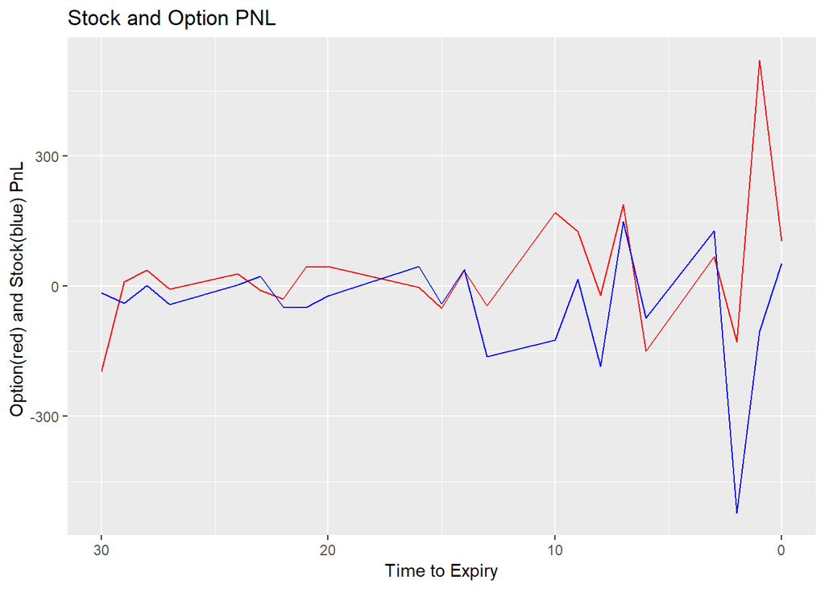

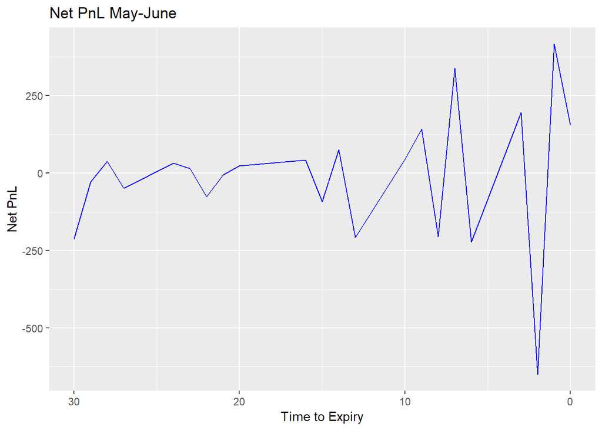

```
## Final Net cumulative profit for this month  -230.1415
```

```
## character(0)
```

# MONTH JUNE-JULY

| date | Close | IV30 | Previous_Close | monthnumber | premium | Option_DoD_PnL | delta_hedge | Hedging_DoD_Pnl | Net_PnL |
| --- | --- | --- | --- | --- | --- | --- | --- | --- | --- |
| 2018-06-15 | 139.57 | 17.3 | 139.82 | 7 | 1.8133761 | -181.3376056 | -39 | 9.75 | -171.5876056 |
| 2018-06-18 | 138.99 | 16.9 | 139.57 | 7 | 1.5697762 | -24.3599881 | -37 | 21.46 | -2.8999881 |
| 2018-06-19 | 138.60 | 17.6 | 138.99 | 7 | 1.3166781 | -25.3098089 | -33 | 12.87 | -12.4398089 |
| 2018-06-20 | 137.79 | 16.8 | 138.60 | 7 | 1.1441799 | -17.2498192 | -30 | 24.30 | 7.0501808 |
| 2018-06-21 | 138.21 | 17.5 | 137.79 | 7 | 0.8719451 | -27.2234832 | -25 | -10.50 | -37.7234832 |
| 2018-06-22 | 139.09 | 17.2 | 138.21 | 7 | 0.9366699 | 6.4724798 | -27 | -23.76 | -17.2875202 |
| 2018-06-25 | 136.63 | 18.9 | 139.09 | 7 | 1.0402339 | 10.3564037 | -31 | 76.26 | 86.6164037 |
| 2018-06-26 | 135.09 | 18.9 | 136.63 | 7 | 0.4242772 | -61.5956742 | -16 | 24.64 | -36.9556742 |
| 2018-06-27 | 133.07 | 19.1 | 135.09 | 7 | 0.2023584 | -22.1918717 | -9 | 18.18 | -4.0118717 |
| 2018-06-28 | 134.25 | 19.6 | 133.07 | 7 | 0.0635058 | -13.8852597 | -3 | -3.54 | -17.4252597 |
| 2018-06-29 | 134.14 | 19.5 | 134.25 | 7 | 0.0996144 | 3.6108565 | -5 | 0.55 | 4.1608565 |
| 2018-07-02 | 134.86 | 22.2 | 134.14 | 7 | 0.0484194 | -5.1195042 | -3 | -2.16 | -7.2795042 |
| 2018-07-03 | 133.66 | 24.1 | 134.86 | 7 | 0.0587270 | 1.0307680 | -4 | 4.80 | 5.8307680 |
| 2018-07-05 | 133.71 | 24.5 | 133.66 | 7 | 0.0111984 | -4.7528609 | -1 | -0.05 | -4.8028609 |
| 2018-07-06 | 134.22 | 24.7 | 133.71 | 7 | 0.0066775 | -0.4520940 | -1 | -0.51 | -0.9620940 |
| 2018-07-09 | 134.52 | 22.8 | 134.22 | 7 | 0.0006657 | -0.6011757 | 0 | 0.00 | -0.6011757 |
| 2018-07-10 | 135.97 | 22.7 | 134.52 | 7 | 0.0001597 | -0.0506012 | 0 | 0.00 | -0.0506012 |
| 2018-07-11 | 135.37 | 23.4 | 135.97 | 7 | 0.0001658 | 0.0006040 | 0 | 0.00 | 0.0006040 |
| 2018-07-12 | 137.50 | 23.0 | 135.37 | 7 | 0.0000000 | -0.0165751 | 0 | 0.00 | -0.0165751 |
| 2018-07-13 | 137.34 | 23.3 | 137.50 | 7 | 0.0000000 | -0.0000015 | 0 | 0.00 | -0.0000015 |

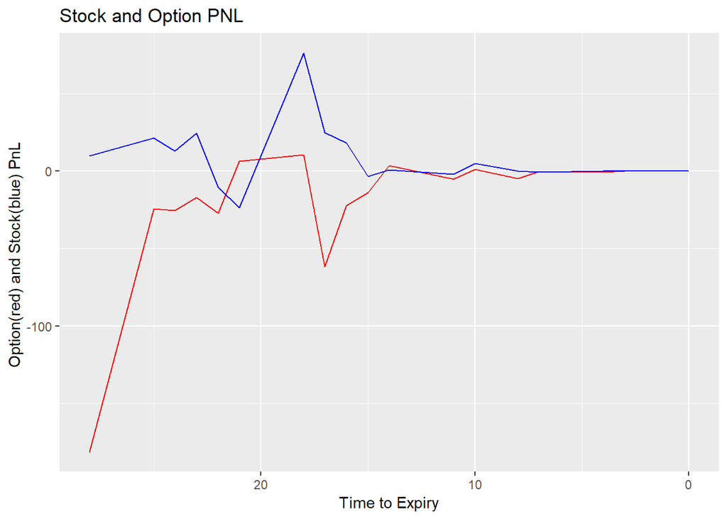

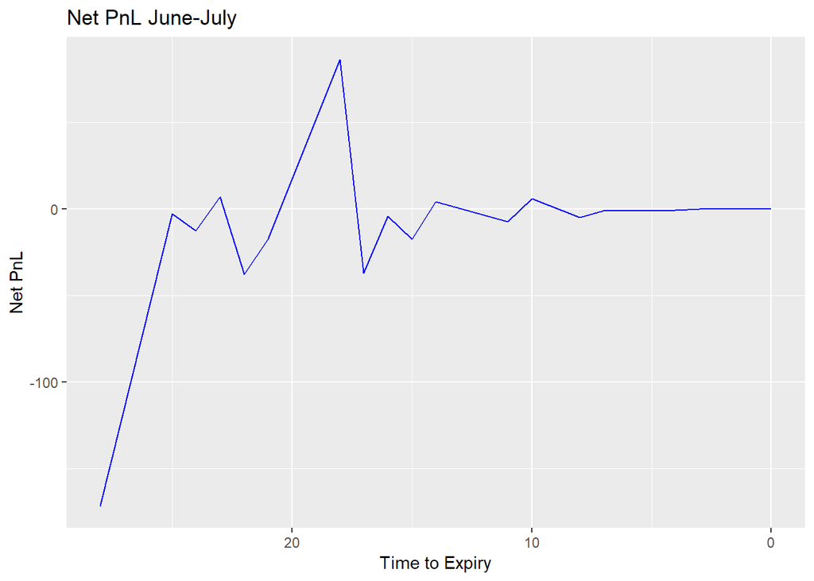

```
## Final Net cumulative profit for this month  -210.3852
```

```
## character(0)
```

# MONTH JULY-AUGUST

| date | Close | IV30 | Previous_Close | monthnumber | premium | Option_DoD_PnL | delta_hedge | Hedging_DoD_Pnl | Net_PnL |
| --- | --- | --- | --- | --- | --- | --- | --- | --- | --- |
| 2018-07-16 | 137.12 | 22.6 | 137.34 | 8 | 2.4256899 | -242.5689915 | -40 | 8.80 | -233.768991 |
| 2018-07-17 | 137.36 | 22.6 | 137.12 | 8 | 2.2773385 | -14.8351409 | -39 | -9.36 | -24.195141 |
| 2018-07-18 | 137.50 | 22.4 | 137.36 | 8 | 2.3098451 | 3.2506588 | -40 | -5.60 | -2.349341 |
| 2018-07-19 | 137.06 | 22.9 | 137.50 | 8 | 2.3022834 | -0.7561723 | -40 | 17.60 | 16.843828 |
| 2018-07-20 | 137.33 | 22.6 | 137.06 | 8 | 2.0661874 | -23.6095942 | -38 | -10.26 | -33.869594 |
| 2018-07-23 | 137.70 | 21.5 | 137.33 | 8 | 1.9701638 | -9.6023611 | -38 | -14.06 | -23.662361 |
| 2018-07-24 | 137.11 | 21.8 | 137.70 | 8 | 2.0445669 | 7.4403081 | -40 | 23.60 | 31.040308 |
| 2018-07-25 | 139.15 | 21.9 | 137.11 | 8 | 1.7492177 | -29.5349224 | -36 | -73.44 | -102.974922 |
| 2018-07-26 | 139.24 | 21.7 | 139.15 | 8 | 2.5232841 | 77.4066386 | -47 | -4.23 | 73.176639 |
| 2018-07-27 | 137.41 | 22.1 | 139.24 | 8 | 2.4864961 | -3.6787988 | -47 | 86.01 | 82.331201 |
| 2018-07-30 | 134.29 | 23.1 | 137.41 | 8 | 1.4816338 | -100.4862231 | -36 | 112.32 | 11.833777 |
| 2018-07-31 | 134.99 | 25.0 | 134.29 | 8 | 0.5811484 | -90.0485399 | -18 | -12.60 | -102.648540 |
| 2018-08-01 | 132.61 | 19.3 | 134.99 | 8 | 0.6564479 | 7.5299439 | -21 | 49.98 | 57.509944 |
| 2018-08-02 | 133.15 | 18.3 | 132.61 | 8 | 0.2490786 | -40.7369266 | -10 | -5.40 | -46.136927 |
| 2018-08-03 | 134.25 | 16.9 | 133.15 | 8 | 0.2623668 | 1.3288137 | -11 | -12.10 | -10.771186 |
| 2018-08-06 | 135.56 | 16.3 | 134.25 | 8 | 0.2358670 | -2.6499773 | -11 | -14.41 | -17.059977 |
| 2018-08-07 | 137.91 | 15.7 | 135.56 | 8 | 0.3463046 | 11.0437665 | -16 | -37.60 | -26.556234 |
| 2018-08-08 | 137.82 | 15.9 | 137.91 | 8 | 0.7848829 | 43.8578239 | -31 | 2.79 | 46.647824 |
| 2018-08-09 | 138.37 | 16.0 | 137.82 | 8 | 0.6356364 | -14.9246520 | -28 | -15.40 | -30.324652 |
| 2018-08-10 | 139.29 | 16.5 | 138.37 | 8 | 0.6646213 | 2.8984944 | -32 | -29.44 | -26.541506 |
| 2018-08-13 | 139.67 | 16.8 | 139.29 | 8 | 0.3661790 | -29.8442284 | -34 | -12.92 | -42.764228 |
| 2018-08-14 | 141.15 | 16.1 | 139.67 | 8 | 0.0000000 | -36.6179022 | 0 | 0.00 | -36.617902 |

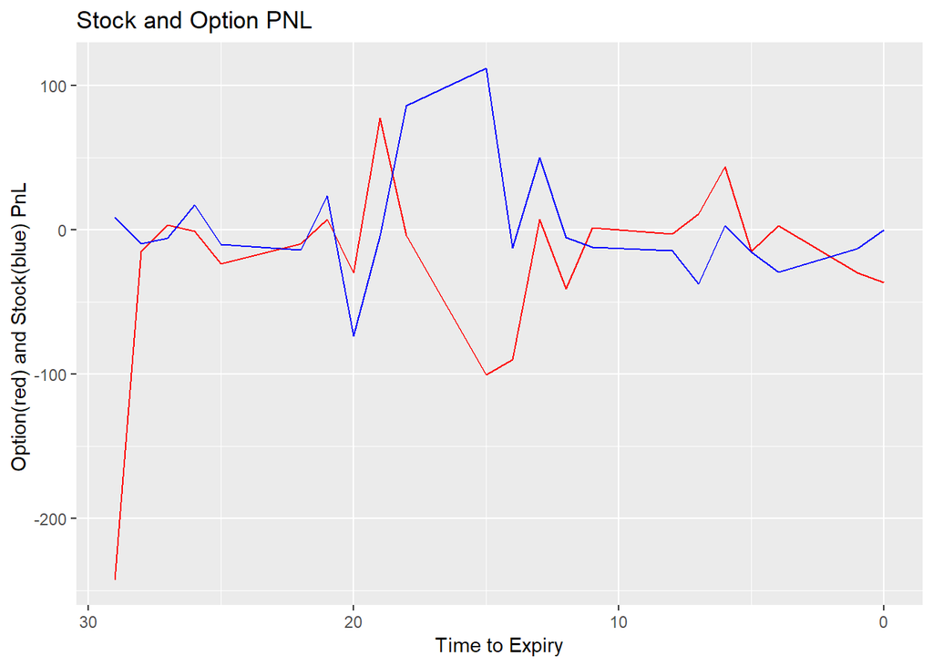

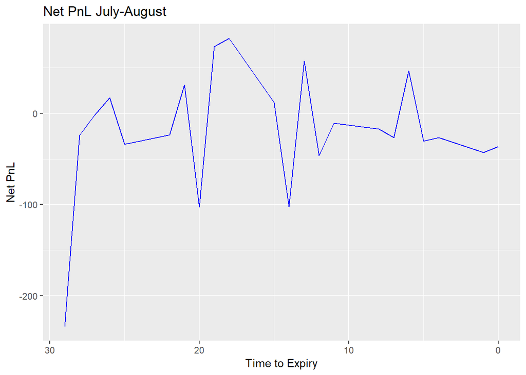

```
## Final Net cumulative profit for this month  -440.858
```

```
## character(0)
```

# MONTH AUGUST-SEPTEMBER

| date | Close | IV30 | Previous_Close | monthnumber | premium | Option_DoD_PnL | delta_hedge | Hedging_DoD_Pnl | Net_PnL |
| --- | --- | --- | --- | --- | --- | --- | --- | --- | --- |
| 2018-08-15 | 141.24 | 17.0 | 141.15 | 9 | 2.016101 | -201.610130 | -42 | -3.78 | -205.390130 |
| 2018-08-16 | 141.24 | 15.7 | 141.24 | 9 | 2.005732 | -1.036913 | -42 | 0.00 | -1.036913 |
| 2018-08-17 | 142.55 | 15.1 | 141.24 | 9 | 1.956996 | -4.873665 | -42 | -55.02 | -59.893665 |
| 2018-08-20 | 142.16 | 14.6 | 142.55 | 9 | 2.396128 | 43.913281 | -49 | 19.11 | 63.023281 |
| 2018-08-21 | 143.04 | 14.3 | 142.16 | 9 | 2.155281 | -24.084689 | -47 | -41.36 | -65.444689 |
| 2018-08-22 | 143.30 | 14.9 | 143.04 | 9 | 2.533991 | 37.871004 | -52 | -13.52 | 24.351004 |
| 2018-08-23 | 143.35 | 14.9 | 143.30 | 9 | 2.614799 | 8.080727 | -54 | -2.70 | 5.380727 |
| 2018-08-24 | 143.59 | 14.7 | 143.35 | 9 | 2.583577 | -3.122209 | -54 | -12.96 | -16.082209 |
| 2018-08-27 | 143.60 | 16.0 | 143.59 | 9 | 2.532894 | -5.068309 | -56 | -0.56 | -5.628309 |
| 2018-08-28 | 143.83 | 17.3 | 143.60 | 9 | 2.474485 | -5.840874 | -56 | -12.88 | -18.720875 |
| 2018-08-29 | 146.35 | 16.7 | 143.83 | 9 | 2.540097 | 6.561250 | -58 | -146.16 | -139.598750 |
| 2018-08-30 | 145.49 | 17.0 | 146.35 | 9 | 4.174262 | 163.416507 | -76 | 65.36 | 228.776507 |
| 2018-08-31 | 146.75 | 16.6 | 145.49 | 9 | 3.479931 | -69.433149 | -71 | -89.46 | -158.893149 |
| 2018-09-04 | 145.81 | 17.3 | 146.75 | 9 | 4.201225 | 72.129435 | -83 | 78.02 | 150.149435 |
| 2018-09-05 | 146.14 | 16.6 | 145.81 | 9 | 3.381651 | -81.957455 | -78 | -25.74 | -107.697455 |
| 2018-09-06 | 147.28 | 16.9 | 146.14 | 9 | 3.575158 | 19.350737 | -81 | -92.34 | -72.989263 |
| 2018-09-07 | 146.73 | 16.4 | 147.28 | 9 | 4.495073 | 91.991486 | -90 | 49.50 | 141.491486 |
| 2018-09-10 | 147.02 | 16.0 | 146.73 | 9 | 3.840658 | -65.441525 | -93 | -26.97 | -92.411525 |
| 2018-09-11 | 147.00 | 16.6 | 147.02 | 9 | 4.071900 | 23.124285 | -97 | 1.94 | 25.064285 |
| 2018-09-12 | 147.13 | 15.9 | 147.00 | 9 | 4.022680 | -4.922094 | -99 | -12.87 | -17.792094 |
| 2018-09-13 | 146.92 | 16.3 | 147.13 | 9 | 4.137117 | 11.443790 | -100 | 21.00 | 32.443790 |
| 2018-09-14 | 147.46 | 15.8 | 146.92 | 9 | 3.920000 | -21.711749 | -100 | -54.00 | -75.711749 |

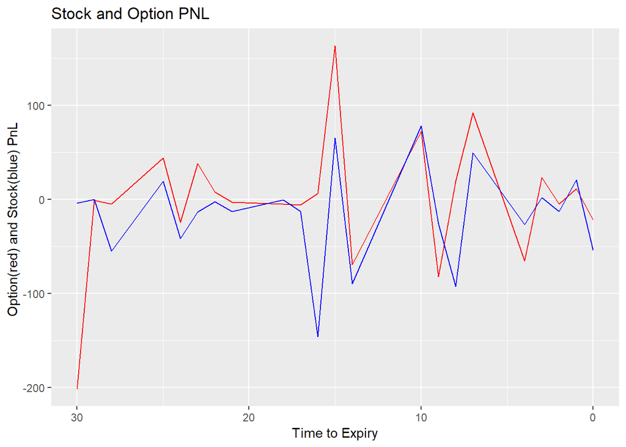

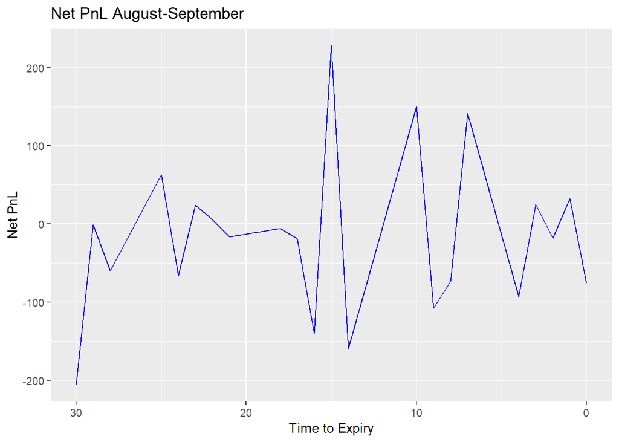

```
## Final Net cumulative profit for this month  -366.6103
```

```
## character(0)
```

# MONTH SEPTEMBER-OCTOBER

| date | Close | IV30 | Previous_Close | monthnumber | premium | Option_DoD_PnL | delta_hedge | Hedging_DoD_Pnl | Net_PnL |
| --- | --- | --- | --- | --- | --- | --- | --- | --- | --- |
| 2018-09-17 | 147.04 | 15.2 | 147.46 | 10 | 1.7328233 | -173.282331 | -42 | 17.64 | -155.64233 |
| 2018-09-18 | 147.56 | 15.0 | 147.04 | 10 | 1.5157958 | -21.702756 | -39 | -20.28 | -41.98276 |
| 2018-09-19 | 146.97 | 15.1 | 147.56 | 10 | 1.6752221 | 15.942631 | -42 | 24.78 | 40.72263 |
| 2018-09-20 | 148.88 | 14.6 | 146.97 | 10 | 1.3910367 | -28.418535 | -37 | -70.67 | -99.08854 |
| 2018-09-21 | 150.68 | 14.4 | 148.88 | 10 | 2.1804730 | 78.943628 | -51 | -91.80 | -12.85637 |
| 2018-09-24 | 149.07 | 14.7 | 150.68 | 10 | 3.0492173 | 86.874426 | -65 | 104.65 | 191.52443 |
| 2018-09-25 | 148.89 | 15.7 | 149.07 | 10 | 2.0468785 | -100.233878 | -52 | 9.36 | -90.87388 |
| 2018-09-26 | 149.62 | 15.7 | 148.89 | 10 | 1.8924683 | -15.441021 | -51 | -37.23 | -52.67102 |
| 2018-09-27 | 149.91 | 15.3 | 149.62 | 10 | 2.2213189 | 32.885066 | -57 | -16.53 | 16.35507 |
| 2018-09-28 | 150.66 | 15.7 | 149.91 | 10 | 2.3249705 | 10.365159 | -60 | -45.00 | -34.63484 |
| 2018-10-01 | 150.74 | 18.3 | 150.66 | 10 | 2.5963254 | 27.135489 | -67 | -5.36 | 21.77549 |
| 2018-10-02 | 151.77 | 19.3 | 150.74 | 10 | 2.5800206 | -1.630479 | -69 | -71.07 | -72.70048 |
| 2018-10-03 | 151.59 | 20.6 | 151.77 | 10 | 3.2735966 | 69.357594 | -79 | 14.22 | 83.57759 |
| 2018-10-04 | 150.22 | 22.8 | 151.59 | 10 | 3.0661226 | -20.747397 | -79 | 108.23 | 87.48260 |
| 2018-10-05 | 150.99 | 23.1 | 150.22 | 10 | 1.9919264 | -107.419622 | -66 | -50.82 | -158.23962 |
| 2018-10-08 | 149.30 | 23.3 | 150.99 | 10 | 2.2829489 | 29.102256 | -80 | 135.20 | 164.30226 |
| 2018-10-09 | 150.14 | 23.9 | 149.30 | 10 | 0.9905507 | -129.239825 | -56 | -47.04 | -176.27982 |
| 2018-10-10 | 141.78 | 27.1 | 150.14 | 10 | 1.4004522 | 40.990147 | -76 | 635.36 | 676.35015 |
| 2018-10-11 | 138.18 | 31.3 | 141.78 | 10 | 0.0000000 | -140.045216 | 0 | 0.00 | -140.04522 |
| 2018-10-12 | 140.72 | 28.6 | 138.18 | 10 | 0.0000000 | 0.000000 | 0 | 0.00 | 0.00000 |

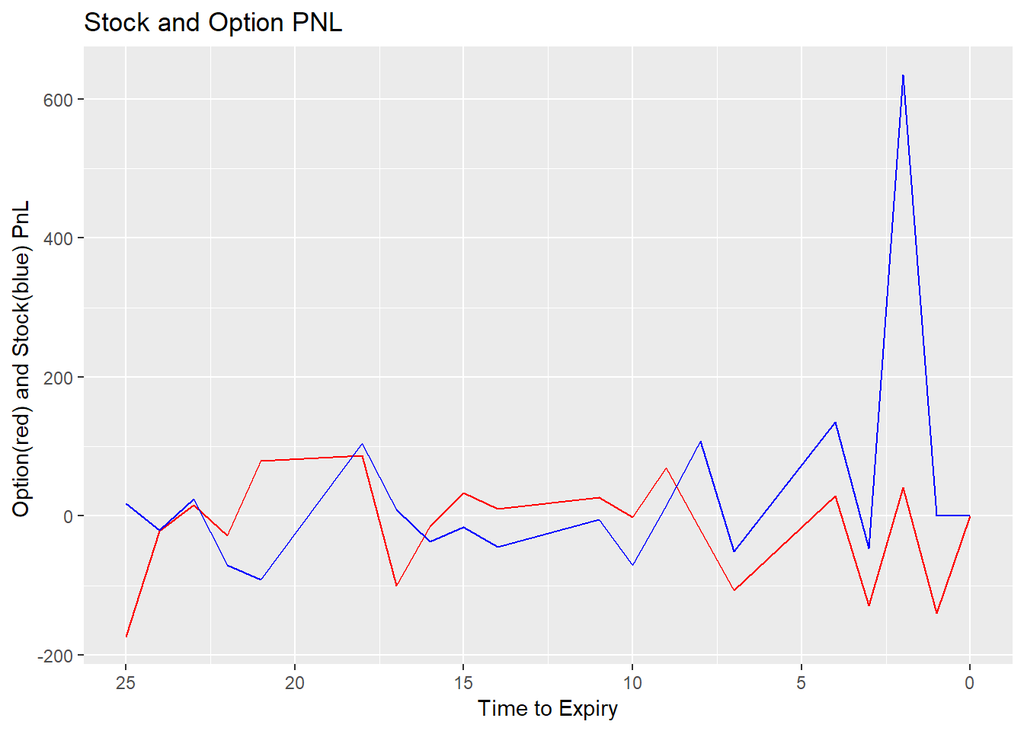

[figure not shown]

```
## Final Net cumulative profit for this month  247.0753
```

```
## character(0)
```

# MONTH OCTOBER-NOVEMBER

| date | Close | IV30 | Previous_Close | monthnumber | premium | Option_DoD_PnL | delta_hedge | Hedging_DoD_Pnl | Net_PnL |
| --- | --- | --- | --- | --- | --- | --- | --- | --- | --- |
| 2018-10-15 | 140.25 | 28.4 | 140.72 | 11 | 3.2461204 | -324.612035 | -41 | 19.27 | -305.342035 |
| 2018-10-16 | 143.28 | 25.9 | 140.25 | 11 | 2.9800663 | -26.605402 | -39 | -118.17 | -144.775402 |
| 2018-10-17 | 143.66 | 25.1 | 143.28 | 11 | 4.2468137 | 126.674738 | -50 | -19.00 | 107.674738 |
| 2018-10-18 | 142.92 | 26.0 | 143.66 | 11 | 4.3537284 | 10.691472 | -51 | 37.74 | 48.431472 |
| 2018-10-19 | 143.41 | 26.1 | 142.92 | 11 | 3.9005695 | -45.315897 | -48 | -23.52 | -68.835897 |
| 2018-10-22 | 143.99 | 25.9 | 143.41 | 11 | 3.8734029 | -2.716656 | -50 | -29.00 | -31.716656 |
| 2018-10-23 | 142.44 | 26.9 | 143.99 | 11 | 4.0751818 | 20.177887 | -52 | 80.60 | 100.777887 |
| 2018-10-24 | 137.65 | 30.3 | 142.44 | 11 | 3.2238100 | -85.137177 | -46 | 220.34 | 135.202823 |
| 2018-10-25 | 140.49 | 29.3 | 137.65 | 11 | 1.4200306 | -180.377941 | -26 | -73.84 | -254.217941 |
| 2018-10-26 | 136.35 | 32.2 | 140.49 | 11 | 2.2301466 | 81.011602 | -37 | 153.18 | 234.191602 |
| 2018-10-29 | 135.30 | 32.0 | 136.35 | 11 | 0.8284791 | -140.166751 | -19 | 19.95 | -120.216751 |
| 2018-10-30 | 137.26 | 31.9 | 135.30 | 11 | 0.5846982 | -24.378095 | -15 | -29.40 | -53.778095 |
| 2018-10-31 | 144.08 | 23.2 | 137.26 | 11 | 0.8598949 | 27.519678 | -21 | -143.22 | -115.700322 |
| 2018-11-01 | 140.91 | 22.7 | 144.08 | 11 | 3.1647293 | 230.483438 | -52 | 164.84 | 395.323438 |
| 2018-11-02 | 140.72 | 23.3 | 140.91 | 11 | 1.6644563 | -150.027300 | -35 | 6.65 | -143.377300 |
| 2018-11-05 | 141.41 | 23.0 | 140.72 | 11 | 1.2416662 | -42.279013 | -31 | -21.39 | -63.669013 |
| 2018-11-06 | 143.92 | 21.6 | 141.41 | 11 | 1.3361971 | 9.453092 | -34 | -85.34 | -75.886908 |
| 2018-11-07 | 148.30 | 19.1 | 143.92 | 11 | 2.2425862 | 90.638907 | -51 | -223.38 | -132.741093 |
| 2018-11-08 | 147.89 | 19.6 | 148.30 | 11 | 4.9634679 | 272.088173 | -80 | 32.80 | 304.888173 |
| 2018-11-09 | 147.19 | 21.9 | 147.89 | 11 | 4.4984337 | -46.503424 | -80 | 56.00 | 9.496576 |
| 2018-11-12 | 144.17 | 23.7 | 147.19 | 11 | 3.4368888 | -106.154490 | -85 | 256.70 | 150.545510 |
| 2018-11-13 | 144.72 | 24.1 | 144.17 | 11 | 0.9457957 | -249.109303 | -54 | -29.70 | -278.809303 |
| 2018-11-14 | 142.72 | 25.9 | 144.72 | 11 | 0.7200000 | -22.579572 | -100 | 200.00 | 177.420428 |

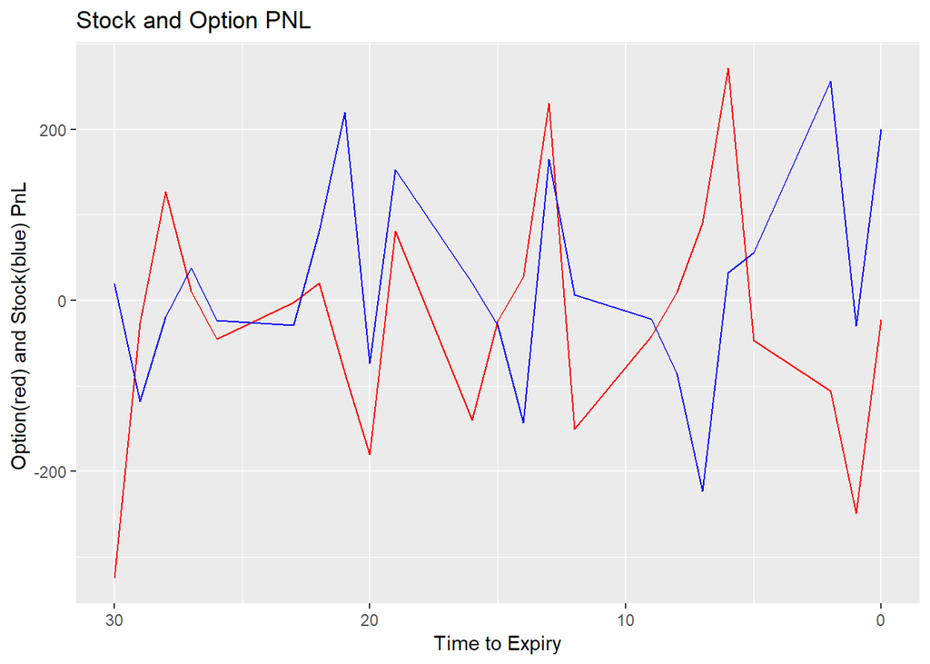

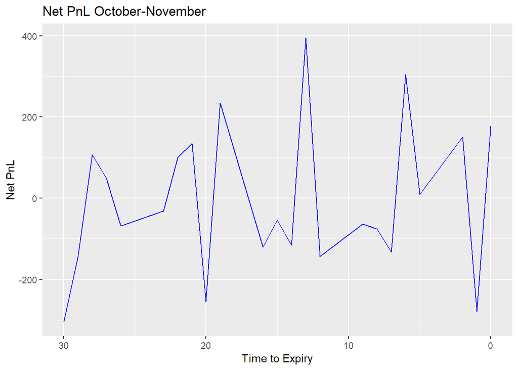

```
## Final Net cumulative profit for this month  -125.1141
```

```
## character(0)
```

# MONTH NOVEMBER-DECEMBER

| date | Close | IV30 | Previous_Close | monthnumber | premium | Option_DoD_PnL | delta_hedge | Hedging_DoD_Pnl | Net_PnL |
| --- | --- | --- | --- | --- | --- | --- | --- | --- | --- |
| 2018-11-15 | 147.25 | 24.4 | 142.72 | 12 | 2.2621883 | -226.2188347 | -35 | -158.55 | -384.7688347 |
| 2018-11-16 | 146.55 | 24.9 | 147.25 | 12 | 4.1926697 | 193.0481376 | -53 | 37.10 | 230.1481376 |
| 2018-11-19 | 143.44 | 27.0 | 146.55 | 12 | 3.6022871 | -59.0382650 | -50 | 155.50 | 96.4617350 |
| 2018-11-20 | 140.52 | 28.5 | 143.44 | 12 | 2.1768815 | -142.5405554 | -37 | 108.04 | -34.5005554 |
| 2018-11-21 | 141.08 | 26.5 | 140.52 | 12 | 1.2190978 | -95.7783714 | -25 | -14.00 | -109.7783714 |
| 2018-11-23 | 140.89 | 26.6 | 141.08 | 12 | 1.2341904 | 1.5092612 | -26 | 4.94 | 6.4492612 |
| 2018-11-26 | 144.65 | 23.0 | 140.89 | 12 | 0.9916666 | -24.2523852 | -23 | -86.48 | -110.7323852 |
| 2018-11-27 | 145.32 | 22.9 | 144.65 | 12 | 2.0754128 | 108.3746262 | -40 | -26.80 | 81.5746262 |
| 2018-11-28 | 148.61 | 21.2 | 145.32 | 12 | 2.2594705 | 18.4057668 | -43 | -141.47 | -123.0642332 |
| 2018-11-29 | 145.85 | 22.0 | 148.61 | 12 | 3.8538905 | 159.4419978 | -60 | 165.60 | 325.0419978 |
| 2018-11-30 | 147.42 | 21.7 | 145.85 | 12 | 2.2963627 | -155.7527742 | -45 | -70.65 | -226.4027742 |
| 2018-12-03 | 147.41 | 19.9 | 147.42 | 12 | 2.7437679 | 44.7405130 | -54 | 0.54 | 45.2805130 |
| 2018-12-04 | 143.61 | 23.7 | 147.41 | 12 | 2.6192761 | -12.4491744 | -54 | 205.20 | 192.7508256 |
| 2018-12-06 | 143.18 | 24.8 | 143.61 | 12 | 0.8353842 | -178.3891897 | -27 | 11.61 | -166.7791897 |
| 2018-12-07 | 139.33 | 26.5 | 143.18 | 12 | 0.6216891 | -21.3695114 | -23 | 88.55 | 67.1804886 |
| 2018-12-10 | 139.73 | 27.8 | 139.33 | 12 | 0.0242719 | -59.7417245 | -2 | -0.80 | -60.5417245 |
| 2018-12-11 | 139.99 | 26.9 | 139.73 | 12 | 0.0120767 | -1.2195187 | -1 | -0.26 | -1.4795187 |
| 2018-12-12 | 139.57 | 26.8 | 139.99 | 12 | 0.0027458 | -0.9330845 | 0 | 0.00 | -0.9330845 |
| 2018-12-13 | 138.20 | 26.4 | 139.57 | 12 | 0.0000101 | -0.2735737 | 0 | 0.00 | -0.2735737 |
| 2018-12-14 | 134.82 | 28.2 | 138.20 | 12 | 0.0000000 | -0.0010091 | 0 | 0.00 | -0.0010091 |

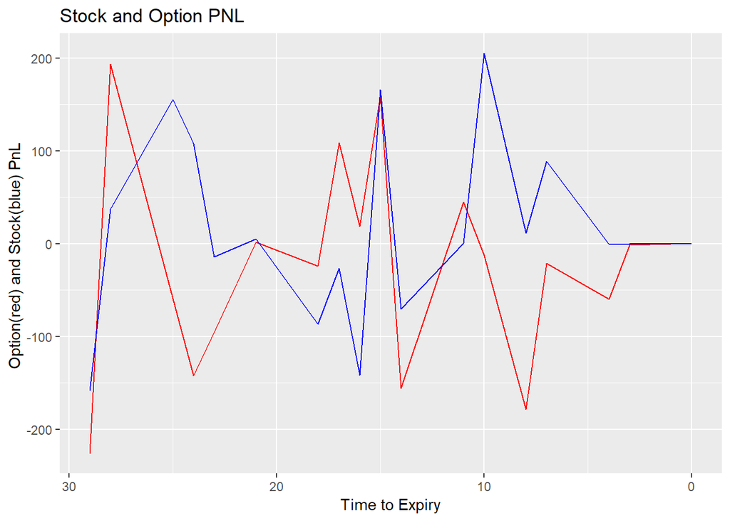

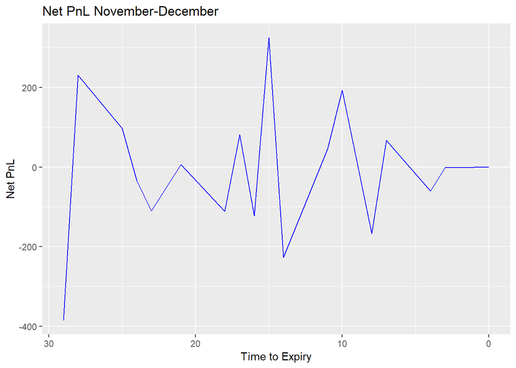

```
## Final Net cumulative profit for this month  -174.3677
```

```
## character(0)
```

# SHARPE RATIO wrt MONTH, MAX DRAWDOWN wrt MONTH

### From MaxDrawDown graph we don’t see any clear pattern to infer .

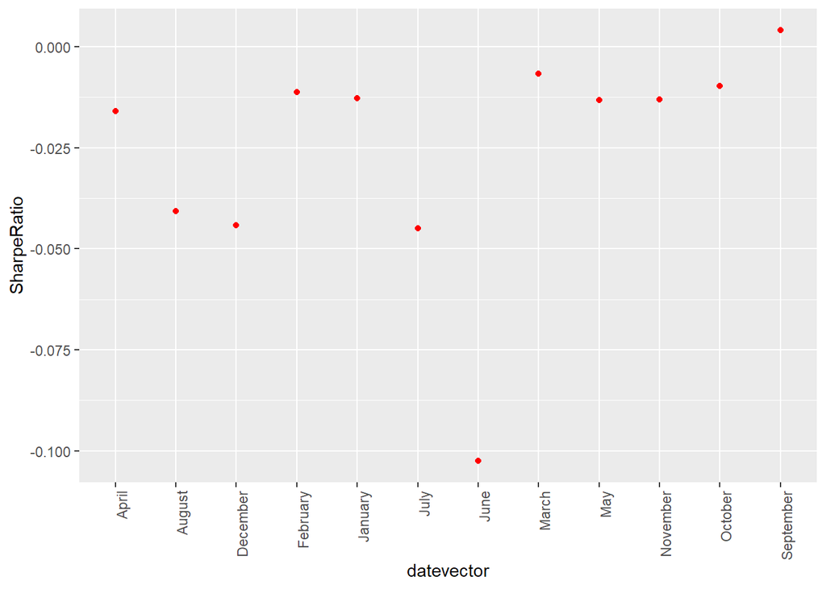

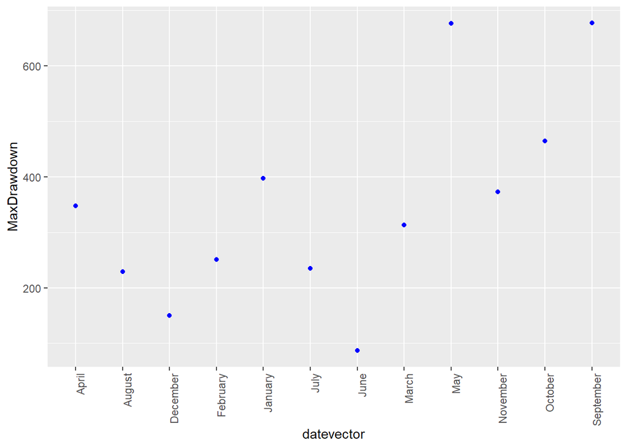

# CHANGING DELTA

### Here we repeat backtesting procedure for entire year of data by changing delta and seeing how the net PnL changes.

### OBSERVATION:As delta increases Net profit for this hedging strategy declines gradually . According to data, delta hedging works better with options that are most out of the money.

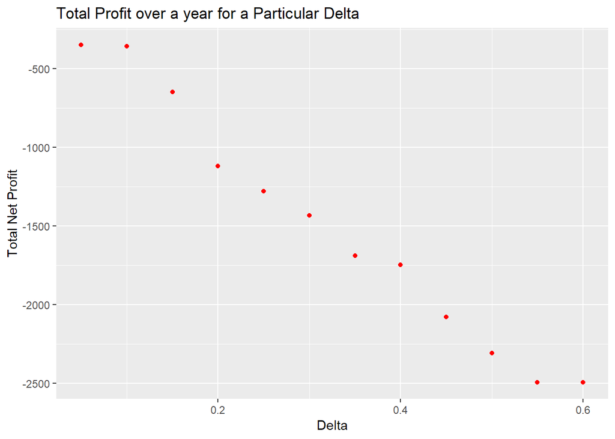